# StudentNoteBook

### Part 3

Lastly we have been working with data. To get this data from a process into your project we have the readr library. For this part, let us have a look at importing data and how to tidy the data. For the first set the code will be given, the second data set you will have to import yourself.

```r
bakeoff <- read_csv("bakeoff.csv", skip = 0,
                    na = c("", "NA", "UNKNOWN"))
#If we want to see the loaded data set, we can use the following two options:
#View(bakeoff)
#str(bakeoff)

view(bakeoff)
```

12. Within the CSV that we have downloaded, some of the entries for showstopper are considered non applicable (na). To find all the entries that are NA we can use the filter option. Complete the filter argument for the bakeoff data to show all na for showstopper.

```r
# Filter rows where showstopper is NA
bakeoff %>%
filter(is.na(showstopper))
```

```
## # A tibble: 21 x 10
##    series episode baker signature technical showstopper result uk_airdate
##     <dbl>   <dbl> <chr> <chr>         <dbl> <chr>       <chr>  <date>
##  1      1       1 Edd   Caramel ~         1 <NA>        IN     2010-08-17
##  2      1       1 Jasm~ Fresh Ma~        NA <NA>        IN     2010-08-17
##  3      1       6 Mira~ Lemon Cu~        NA <NA>        RUNNE~ 2010-09-21
##  4      2       1 Ian   Apple an~        10 <NA>        IN     2011-08-16
##  5      2       1 Jason "Lemon M~         6 <NA>        IN     2011-08-16
##  6      2       1 Urva~ Cherry B~         7 <NA>        IN     2011-08-16
##  7      2       1 Yasm~ Cardamom~         5 <NA>        IN     2011-08-16
##  8      2       1 Holly "Cherry ~         1 <NA>        SB     2011-08-16
##  9      2       2 Ben   Chorizo,~         1 <NA>        IN     2011-08-23
## 10      2       2 Ian   "Stilton~         2 <NA>        IN     2011-08-23
## # ... with 11 more rows, and 2 more variables: us_season <dbl>,
## #   us_airdate <date>
```

13. with the function distinct() we can find all the unique entries for a certain column. Can you show the different values in the column of results by completing this code?

```r
# View distinct results
bakeoff %>%
distinct(result)
```

```
## # A tibble: 6 x 1
##   result
##   <chr>
## 1 IN
## 2 OUT
## 3 RUNNER UP
## 4 WINNER
## 5 SB
## 6 LEFT
```

14. Not only knowing the distinct variable values in a column is useful, also knowing how often these appear. With which command can we find a count of all the values in the column result?

```r
# Count rows for each result
  bakeoff %>%
  count( result )
```

```
## # A tibble: 6 x 2
##   result        n
##   <chr>     <int>
## 1 IN          393
## 2 LEFT          1
## 3 OUT          70
## 4 RUNNER UP    16
## 5 SB           61
## 6 WINNER        8
```

15. We want to find the number of episodes per season, to get this we need to do two steps: first we make an overview of the count of series and episodes. You can use the same command as we used in the previous assignment, though now for the series and episodes.

```r
bakeoff %>%
 count( series ,episode )
```

```
## # A tibble: 74 x 3
##    series episode     n
##     <dbl>   <dbl> <int>
##  1      1       1    10
##  2      1       2     8
##  3      1       3     6
##  4      1       4     5
##  5      1       5     4
##  6      1       6     3
##  7      2       1    12
##  8      2       2    11
##  9      2       3    10
## 10      2       4     8
## # ... with 64 more rows
```

16. In question 15 you have made a new table. We will continue with this table in the next step. Count the number of episodes within each series. Complete the code below:

```r
bakeoff %>%
 count( series ,episode ) %>% count(series)
```

```
## # A tibble: 8 x 2
##   series     n
##    <dbl> <int>
## 1      1     6
## 2      2     8
## 3      3    10
## 4      4    10
## 5      5    10
## 6      6    10
## 7      7    10
## 8      8    10
```

### BONUS

17. Now that we know how many episodes there are in a series, we will look at the viewers that tuned in with each episode. In order to do this we need to load a new data set. We have the messy_ratings.csv file. Load this file into your notebook by completing this code:

```r
ratings <- read_csv("messy_ratings.csv",na = c("", "NA", "UNKNOWN"))
# Gather viewer columns and remove NA rows that are in the data set, you can use this code without alterations. Note that we are still interested in the number of viewers per episode.
tidy_ratings <- ratings %>%
    gather(key = "episode", value ="viewers", -series, na.rm = TRUE)
```

18. We need to clean our data to a tidy table. A tidy table means that we create a long table with the seasons as the leading value. Complete the code:

```r
# Adapt code to parse episode as a number
tidy_ratings <- ratings %>%
    gather(  key = "episode", value = "viewers"  , - series  , na.rm = TRUE) %>%
    mutate(episode = parse_number(episode))
```

19. We want to see only the number of viewers in episode 1 and in the last aired episode. For this you can complete the following code:

```r
# Fill in blanks to get first/last data
tidy_ratings %>%
    group_by(series) %>%
    filter(episode == "1" | episode == max(episode)) %>%
    ungroup()
```

```
## # A tibble: 16 x 3
##    series episode viewers
##     <dbl>   <dbl>   <dbl>
##  1      1       1    2.24
##  2      2       1    3.1
##  3      3       1    3.85
##  4      4       1    6.6
##  5      5       1    8.51
##  6      6       1   11.6
##  7      7       1   13.6
##  8      8       1    9.46
##  9      1       6    2.75
## 10      2       8    5.06
## 11      3      10    6.74
## 12      4      10    9.45
## 13      5      10   13.5
## 14      6      10   15.0
## 15      7      10   15.9
## 16      8      10   10.0
```

As we now have the first and last episode in one tidy table, the next step is to recode episode 1 as “first” and the last as “last”. We use the following code:

```r
# Recode first/last episodes
first_last <- tidy_ratings %>% group_by(series) %>%
    filter(episode == "1" | episode == max(episode)) %>%
    ungroup() %>%
  mutate(episode = recode(episode, `1` = "first", .default = "last"))

first_last
```

```
## # A tibble: 16 x 3
##    series episode viewers
##     <dbl> <chr>     <dbl>
##  1      1 first      2.24
##  2      2 first      3.1
##  3      3 first      3.85
##  4      4 first      6.6
##  5      5 first      8.51
##  6      6 first     11.6
##  7      7 first     13.6
##  8      8 first      9.46
##  9      1 last       2.75
## 10      2 last       5.06
## 11      3 last       6.74
## 12      4 last       9.45
## 13      5 last      13.5
## 14      6 last      15.0
## 15      7 last      15.9
## 16      8 last      10.0
```

20. the next step is to make a scatter plot with the different points. To show the jump in viewers a line is drawn through the points for each season.

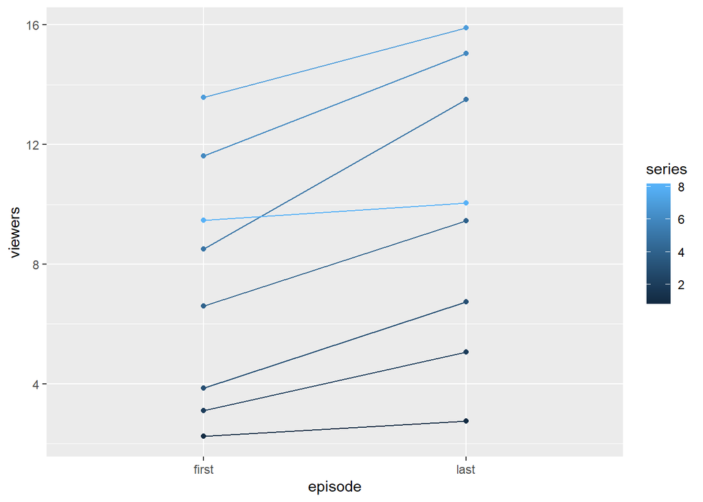

```r
# Fill in to make slope chart
ggplot(first_last, aes(x = episode, y =viewers, color = series)) +
  geom_point() +
  geom_line(aes(group = series))
```

```r
# Let's reset the object for the first_last.
first_last <- tidy_ratings %>%
  group_by(series) %>%
    filter(episode == "1" | episode == max(episode)) %>%
    ungroup() %>%
  mutate(episode = recode(episode, `1` = "first", .default = "last"))
```

21. The next step is to flip the coordinates (hint, add the command to flip the coord. to the next chunk). Complete the code to get the next graph.

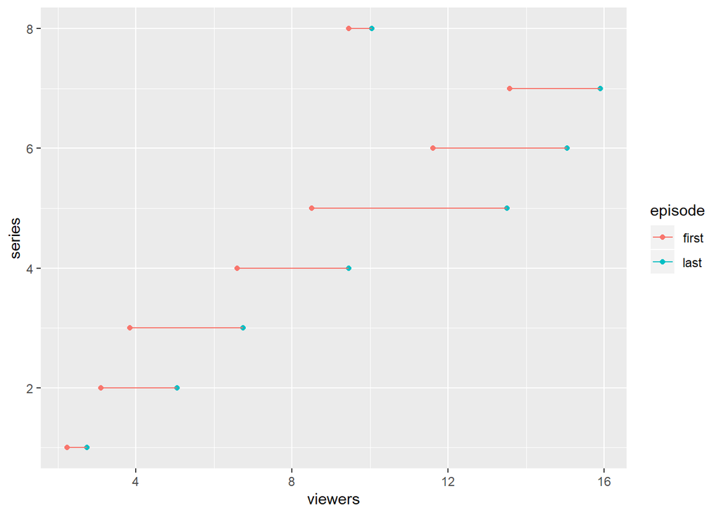

```r
# Switch the variables mapping x-axis and color
ggplot(first_last, aes(x = viewers, y = series, color = episode)) +
  geom_point() +
  geom_line(aes(group = series))
```

```r
# Calculate relative increase in viewers
bump_by_series <- first_last %>%
  spread(episode, viewers) %>%    #??
  mutate(bump = (viewers - episode) /series) #??
```

```
## Error: object 'viewers' not found
```

```r
ggplot(bump_by_series, aes(x = series, y = bump)) +
  geom_col() +
  scale_y_continuous(labels = scales::percent) # converts to %
```

[output not shown]

## End of exam

Make sure you submit the StudentNoteBook, the two .CSV files and the knitted HTML in the Exam_HandIn folder, before you submit your efit exam.

This notebook is now complete. You can make this into a HTML by pressing the “knit” option at the top of your workfield, or select the dropdown by clicking “preview” and “knit to HTML”. Or the key combination: “shift + ctrl + k” When complete you add the 2 .CSV files, your notebook and the HTML to the submission folder.

If you could not finish all questions, or if you could not knit your notebook, you don’t have to add an HTML to your submission.

The Bonus question is for the Good and Outstanding grades specifically.

Week 6 exam NJ2019, Course Based, Data Design Orienting, Semester 1.